# IBM Data Analysis with R Final Project

Hamza Ayed

2022-10-20

Hello my name is **Hamza Ayed**, below is a project that I completed as part of the IBM Data Analysis with R project. In this assignment we were tasked with developing a model to predict precipitation based on certain variables. To improve this assignment I have created this R markdown to present my results.

Here is a link to the protocol I followed https://nbviewer.org/urls/cf-courses-data.s3.us.cloud-object-storage.appdomain.cloud/IBM-DA0151EN-SkillsNetwork/labs/Final_project/IBM-DS-with-R-2-Data-Analysis-with-R.ipynb.

### Installing and loading required packages

```r
#install.packages("rlang")
#install.packages("tidymodels")
#install.packages("tidyverse")
```

### Load Packages

```r
library(tidymodels)
library(rlang)
library(tidyverse)
```

### Download Dataset fro *URL*

```r
url <- 'https://dax-cdn.cdn.appdomain.cloud/dax-noaa-weather-data-jfk-airport/1.1.4/noaa-weather-sample-data.tar.gz'
download.file(url, destfile = "noaa-weather-sample-data.tar.gz")
```

### Untar the zipped file.

```r
untar("noaa-weather-sample-data.tar.gz", tar = "internal")
df <- read_csv("noaa-weather-sample-data/jfk_weather_sample.csv")
```

### Show df

```r
head(df)
```

```
## # A tibble: 6 × 9
##   DATE                HOURLYDe…¹ HOURL…² HOURL…³ HOURL…⁴ HOURL…⁵ HOURL…⁶ HOURL…⁷
##   <dttm>                   <dbl>   <dbl>   <dbl>   <dbl> <chr>     <dbl>   <dbl>
## 1 2015-07-25 13:51:00         60      46      83      68 0.00         13    30.0
## 2 2016-11-18 23:51:00         34      48      53      44 0.00          6    30.0
## 3 2013-01-06 08:51:00         33      89      36      35 0.00         13    30.1
## 4 2011-01-27 16:51:00         18      48      36      30 0.00         14    29.8
## 5 2015-01-03 12:16:00         27      61      39      34 T            11    NA
## 6 2013-02-15 20:51:00         35      79      41      38 0.00          6    29.9
## # … with 1 more variable: HOURLYStationPressure <dbl>, and abbreviated variable
## #   names ¹HOURLYDewPointTempF, ²HOURLYRelativeHumidity, ³HOURLYDRYBULBTEMPF,
## #   ⁴HOURLYWETBULBTEMPF, ⁵HOURLYPrecip, ⁶HOURLYWindSpeed,
## #   ⁷HOURLYSeaLevelPressure
```

```r
glimpse(df)
```

```
## Rows: 5,727
## Columns: 9
## $ DATE                   <dttm> 2015-07-25 13:51:00, 2016-11-18 23:51:00, 2013…
## $ HOURLYDewPointTempF    <dbl> 60, 34, 33, 18, 27, 35, 4, 14, 51, 71, 76, 19, …
## $ HOURLYRelativeHumidity <dbl> 46, 48, 89, 48, 61, 79, 51, 65, 90, 94, 79, 37,…
## $ HOURLYDRYBULBTEMPF     <dbl> 83, 53, 36, 36, 39, 41, 19, 24, 54, 73, 83, 44,…
## $ HOURLYWETBULBTEMPF     <dbl> 68, 44, 35, 30, 34, 38, 15, 21, 52, 72, 78, 35,…
## $ HOURLYPrecip           <chr> "0.00", "0.00", "0.00", "0.00", "T", "0.00", "0…
## $ HOURLYWindSpeed        <dbl> 13, 6, 13, 14, 11, 6, 0, 11, 11, 5, 21, 7, 17, …
## $ HOURLYSeaLevelPressure <dbl> 30.01, 30.05, 30.14, 29.82, NA, 29.94, 30.42, 3…
## $ HOURLYStationPressure  <dbl> 29.99, 30.03, 30.12, 29.80, 30.50, 29.92, 30.40…
```

```r
summary(df)
```

```
##       DATE                        HOURLYDewPointTempF HOURLYRelativeHumidity
##  Min.   :2010-01-01 04:51:00.00   Min.   :-14.00      Min.   : 13.00
##  1st Qu.:2012-03-18 08:55:30.00   1st Qu.: 29.00      1st Qu.: 51.00
##  Median :2014-03-20 10:51:00.00   Median : 46.00      Median : 69.00
##  Mean   :2014-04-05 02:21:16.50   Mean   : 43.52      Mean   : 66.89
##  3rd Qu.:2016-05-12 16:21:00.00   3rd Qu.: 59.00      3rd Qu.: 84.00
##  Max.   :2018-07-26 10:51:00.00   Max.   : 79.00      Max.   :100.00
##                                   NA's   :151         NA's   :151
##  HOURLYDRYBULBTEMPF HOURLYWETBULBTEMPF HOURLYPrecip       HOURLYWindSpeed
##  Min.   : 5.0       Min.   : 3.00      Length:5727        Min.   : 0.00
##  1st Qu.:42.0       1st Qu.:37.00      Class :character   1st Qu.: 7.00
##  Median :56.0       Median :51.00      Mode  :character   Median :10.00
##  Mean   :55.6       Mean   :49.91                         Mean   :11.19
##  3rd Qu.:70.0       3rd Qu.:64.00                         3rd Qu.:15.00
##  Max.   :99.0       Max.   :81.00                         Max.   :52.00
##  NA's   :151        NA's   :154                           NA's   :156
##  HOURLYSeaLevelPressure HOURLYStationPressure
##  Min.   :28.71          Min.   :28.69
##  1st Qu.:29.88          1st Qu.:29.85
##  Median :30.02          Median :29.99
##  Mean   :30.03          Mean   :29.99
##  3rd Qu.:30.17          3rd Qu.:30.14
##  Max.   :30.85          Max.   :30.82
##  NA's   :744            NA's   :158
```

### Create subset of df

```r
subset<-select(df,c(HOURLYRelativeHumidity,HOURLYDRYBULBTEMPF,HOURLYPrecip,HOURLYWindSpeed,HOURLYStationPressure))
head(subset,10)
```

```
## # A tibble: 10 × 5
##    HOURLYRelativeHumidity HOURLYDRYBULBTEMPF HOURLYPrecip HOURLYWindSp…¹ HOURL…²
##                     <dbl>              <dbl> <chr>                 <dbl>   <dbl>
##  1                     46                 83 0.00                     13    30.0
##  2                     48                 53 0.00                      6    30.0
##  3                     89                 36 0.00                     13    30.1
##  4                     48                 36 0.00                     14    29.8
##  5                     61                 39 T                        11    30.5
##  6                     79                 41 0.00                      6    29.9
##  7                     51                 19 0.00                      0    30.4
##  8                     65                 24 0.00                     11    30.4
##  9                     90                 54 0.06                     11    30.0
## 10                     94                 73 <NA>                      5    29.9
## # … with abbreviated variable names ¹HOURLYWindSpeed, ²HOURLYStationPressure
```

### Inspect the unique values present in the column HOURLYPrecip (with unique(dataframe$column)) to see these values.

```r
unique( subset$HOURLYPrecip)
```

```
##  [1] "0.00"  "T"     "0.06"  NA      "0.03"  "0.02"  "0.08"  "0.01"  "0.07"
## [10] "0.16"  "0.09"  "0.22"  "0.02s" "0.24"  "0.18"  "0.05"  "0.04"  "0.09s"
## [19] "0.11"  "0.14"  "0.25"  "0.10"  "0.01s" "0.58"  "0.12"  "0.13"  "0.46"
## [28] "1.07"  "1.19"  "0.34"  "0.20"  "0.36s" "0.42"  "0.17"  "0.27"  "0.35"
## [37] "0.31"  "0.33"  "0.23"  "0.26"  "0.28"  "0.75"  "0.19"  "0.36"  "0.03s"
## [46] "0.07s" "0.54"  "0.59"  "0.21"
```

### Convert T value to 0 and remove last letter **s**

```r
subset$HOURLYPrecip[subset$HOURLYPrecip == "T"] <- 0

subset$HOURLYPrecip <- str_remove(subset$HOURLYPrecip, pattern = "s$")
#show again to surly
unique( subset$HOURLYPrecip)
```

```
##  [1] "0.00" "0"    "0.06" NA     "0.03" "0.02" "0.08" "0.01" "0.07" "0.16"
## [11] "0.09" "0.22" "0.24" "0.18" "0.05" "0.04" "0.11" "0.14" "0.25" "0.10"
## [21] "0.58" "0.12" "0.13" "0.46" "1.07" "1.19" "0.34" "0.20" "0.36" "0.42"
## [31] "0.17" "0.27" "0.35" "0.31" "0.33" "0.23" "0.26" "0.28" "0.75" "0.19"
## [41] "0.54" "0.59" "0.21"
```

```r
glimpse(subset)
```

```
## Rows: 5,727
## Columns: 5
## $ HOURLYRelativeHumidity <dbl> 46, 48, 89, 48, 61, 79, 51, 65, 90, 94, 79, 37,…
## $ HOURLYDRYBULBTEMPF     <dbl> 83, 53, 36, 36, 39, 41, 19, 24, 54, 73, 83, 44,…
## $ HOURLYPrecip           <chr> "0.00", "0.00", "0.00", "0.00", "0", "0.00", "0…
## $ HOURLYWindSpeed        <dbl> 13, 6, 13, 14, 11, 6, 0, 11, 11, 5, 21, 7, 17, …
## $ HOURLYStationPressure  <dbl> 29.99, 30.03, 30.12, 29.80, 30.50, 29.92, 30.40…
```

### convert column fro char to numric

```r
subset$HOURLYPrecip <- (as.numeric(subset$HOURLYPrecip))
glimpse(df)
```

```
## Rows: 5,727
## Columns: 9
## $ DATE                   <dttm> 2015-07-25 13:51:00, 2016-11-18 23:51:00, 2013…
## $ HOURLYDewPointTempF    <dbl> 60, 34, 33, 18, 27, 35, 4, 14, 51, 71, 76, 19, …
## $ HOURLYRelativeHumidity <dbl> 46, 48, 89, 48, 61, 79, 51, 65, 90, 94, 79, 37,…
## $ HOURLYDRYBULBTEMPF     <dbl> 83, 53, 36, 36, 39, 41, 19, 24, 54, 73, 83, 44,…
## $ HOURLYWETBULBTEMPF     <dbl> 68, 44, 35, 30, 34, 38, 15, 21, 52, 72, 78, 35,…
## $ HOURLYPrecip           <chr> "0.00", "0.00", "0.00", "0.00", "T", "0.00", "0…
## $ HOURLYWindSpeed        <dbl> 13, 6, 13, 14, 11, 6, 0, 11, 11, 5, 21, 7, 17, …
## $ HOURLYSeaLevelPressure <dbl> 30.01, 30.05, 30.14, 29.82, NA, 29.94, 30.42, 3…
## $ HOURLYStationPressure  <dbl> 29.99, 30.03, 30.12, 29.80, 30.50, 29.92, 30.40…
```

### Rename columns

```r
NOAA_weather2 <- subset %>%
  rename(relative_humidity = HOURLYRelativeHumidity,
         dry_bulb_temp_f = HOURLYDRYBULBTEMPF,
         precip = HOURLYPrecip,
         wind_speed = HOURLYWindSpeed,
         station_pressure = HOURLYStationPressure)
summary(NOAA_weather2)
```

```
##  relative_humidity dry_bulb_temp_f     precip         wind_speed
##  Min.   : 13.00    Min.   : 5.0    Min.   :0.0000   Min.   : 0.00
##  1st Qu.: 51.00    1st Qu.:42.0    1st Qu.:0.0000   1st Qu.: 7.00
##  Median : 69.00    Median :56.0    Median :0.0000   Median :10.00
##  Mean   : 66.89    Mean   :55.6    Mean   :0.0065   Mean   :11.19
##  3rd Qu.: 84.00    3rd Qu.:70.0    3rd Qu.:0.0000   3rd Qu.:15.00
##  Max.   :100.00    Max.   :99.0    Max.   :1.1900   Max.   :52.00
##  NA's   :151       NA's   :151     NA's   :1660     NA's   :156
##  station_pressure
##  Min.   :28.69
##  1st Qu.:29.85
##  Median :29.99
##  Mean   :29.99
##  3rd Qu.:30.14
##  Max.   :30.82
##  NA's   :158
```

### Remove NA from precip column

```r
NOAA_weather2$precip<-replace_na(NOAA_weather2$precip,replace = 0)
summary(NOAA_weather2)
```

```
##  relative_humidity dry_bulb_temp_f     precip          wind_speed
##  Min.   : 13.00    Min.   : 5.0    Min.   :0.00000   Min.   : 0.00
##  1st Qu.: 51.00    1st Qu.:42.0    1st Qu.:0.00000   1st Qu.: 7.00
##  Median : 69.00    Median :56.0    Median :0.00000   Median :10.00
##  Mean   : 66.89    Mean   :55.6    Mean   :0.00465   Mean   :11.19
##  3rd Qu.: 84.00    3rd Qu.:70.0    3rd Qu.:0.00000   3rd Qu.:15.00
##  Max.   :100.00    Max.   :99.0    Max.   :1.19000   Max.   :52.00
##  NA's   :151       NA's   :151                       NA's   :156
##  station_pressure
##  Min.   :28.69
##  1st Qu.:29.85
##  Median :29.99
##  Mean   :29.99
##  3rd Qu.:30.14
##  Max.   :30.82
##  NA's   :158
```

### Exploratory Data Analysis

##### *The next stage was to split the data into training and testing set in a 80:20 ratio.*

```r
set.seed(1234)
NOAA_weather_split <- initial_split(NOAA_weather2, prop = 0.8)
train_data <- training(NOAA_weather_split)
test_data <- testing(NOAA_weather_split)
```

###### The next task was to visualise variables relative_humidity, dry_bulb_temp_f, precip, wind_speed, station_pressure. Using the training data set. I did this using a simple histogram

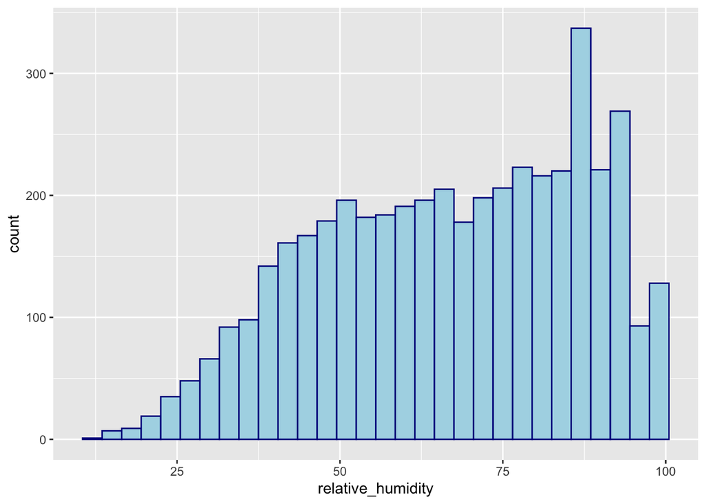

```r
ggplot(train_data, aes(x = relative_humidity))+
  geom_histogram(color = "darkblue", fill = "lightblue")
```

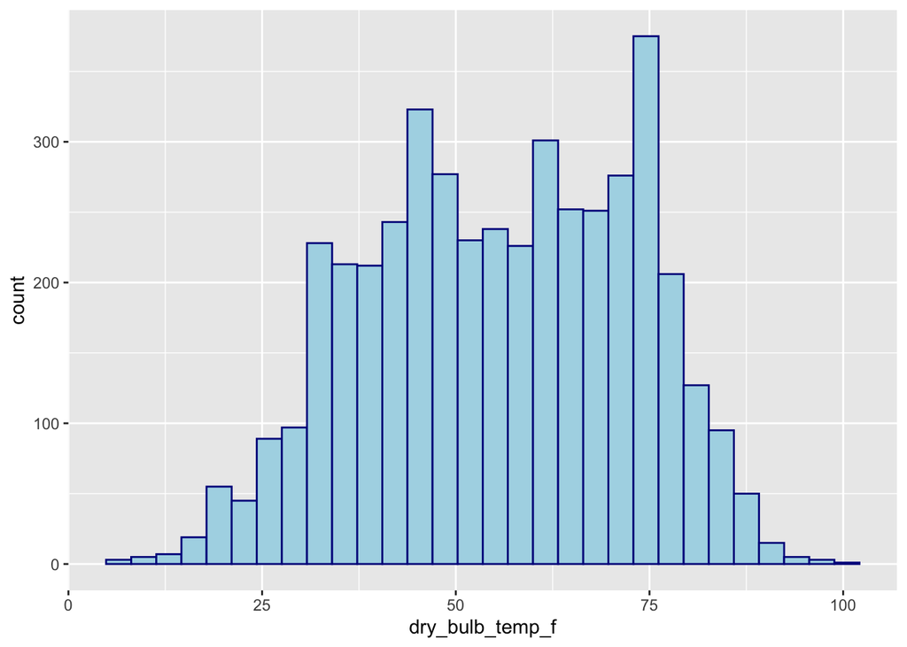

```r
ggplot(train_data, aes(x = dry_bulb_temp_f))+
geom_histogram(color = "darkblue", fill = "lightblue")
```

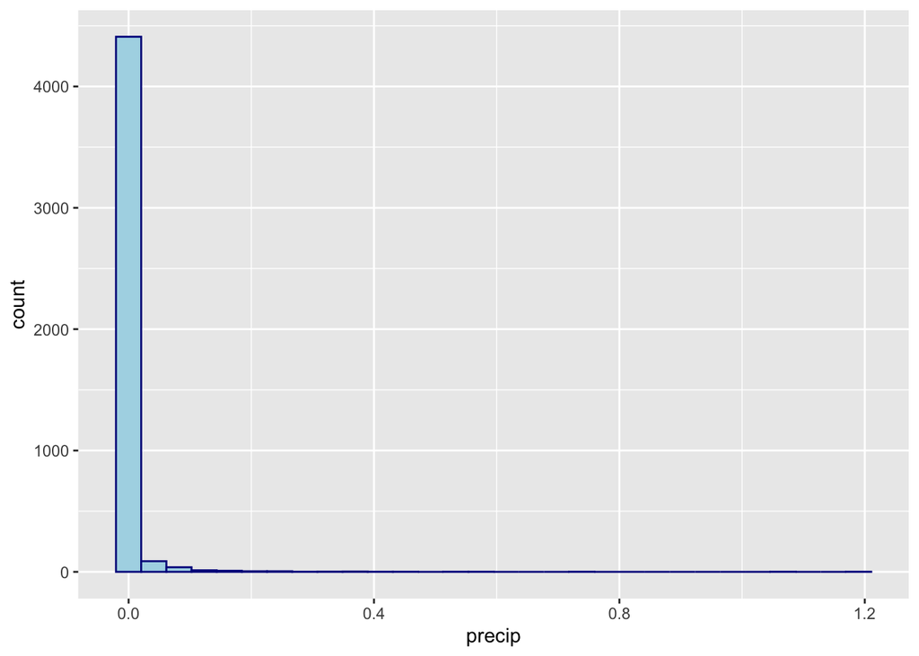

```r
ggplot(train_data, aes(x = precip))+
geom_histogram(color = "darkblue", fill = "lightblue")
```

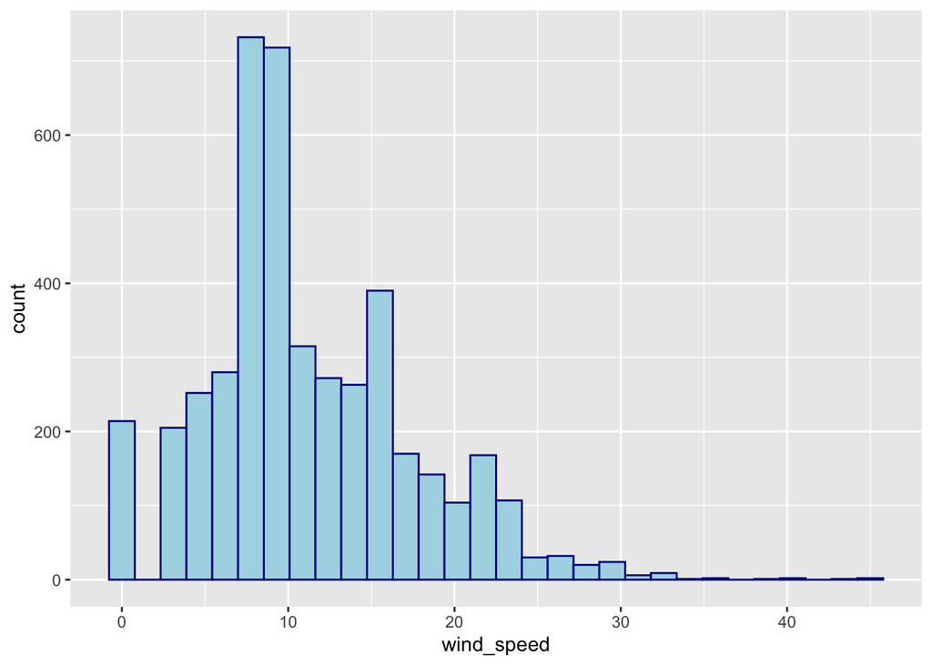

```r
ggplot(train_data, aes(x = wind_speed))+
geom_histogram(color = "darkblue", fill = "lightblue")
```

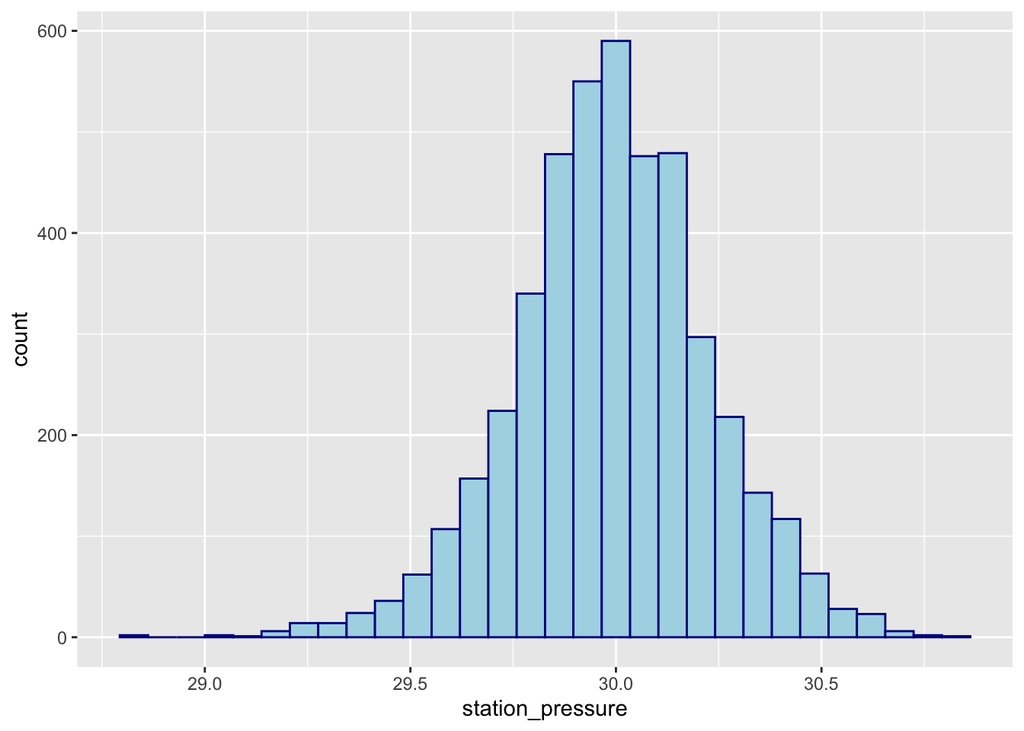

```r
ggplot(train_data, aes(x = station_pressure))+
geom_histogram(color = "darkblue", fill = "lightblue")
```

### Linear Regression

###### After visualising the data I then created a simple linear regression model using precip as the response variable and each of relative_humidity, dry_bulb_temp_f,wind_speed or station_pressure as the predictor variable. As the goal of this assignment was to predict precipitation based on certian variables. The models were then visualised using a scatter plot.

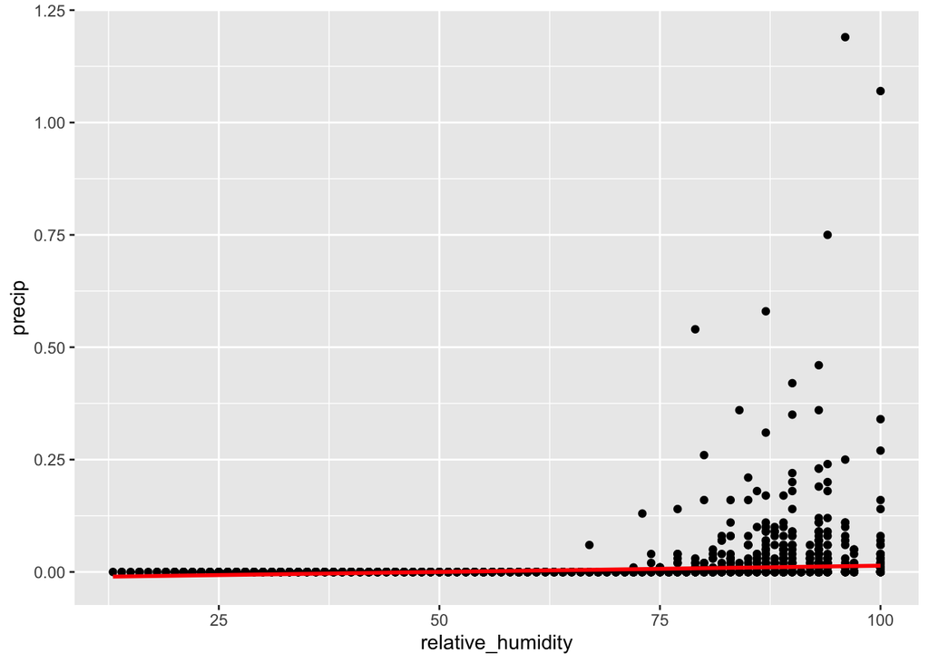

```r
linear_model_humidity <- lm(precip ~ relative_humidity, data = train_data)

ggplot(train_data, aes(x = relative_humidity, y = precip)) +
geom_point() +
stat_smooth(method = "lm", col =  "red")
```

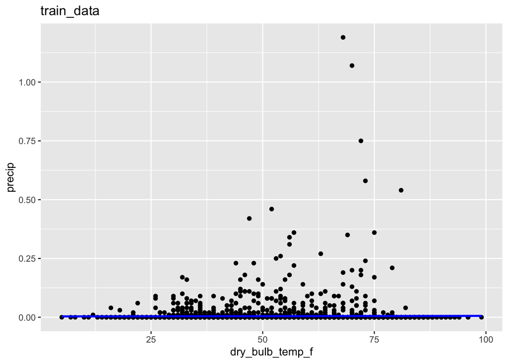

```r
linear_model_drybulbtempf <- lm(precip ~ dry_bulb_temp_f, data = train_data)

ggplot(train_data, aes(x = dry_bulb_temp_f, y = precip)) +
geom_point() +labs(title = 'train_data')+
stat_smooth(method = "lm", col =  "blue")
```

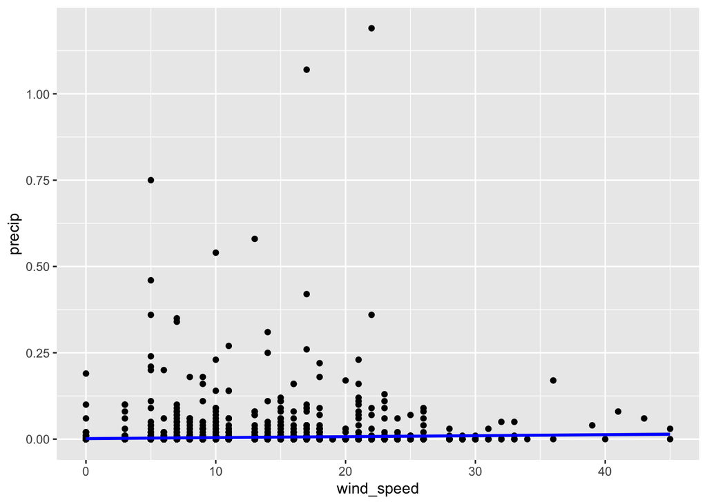

```r
linear_model_windspeed <- lm(precip ~ wind_speed, data = train_data)
ggplot(train_data, aes(x = wind_speed, y = precip)) +
geom_point() +
stat_smooth(method = "lm", col  = "blue")
```

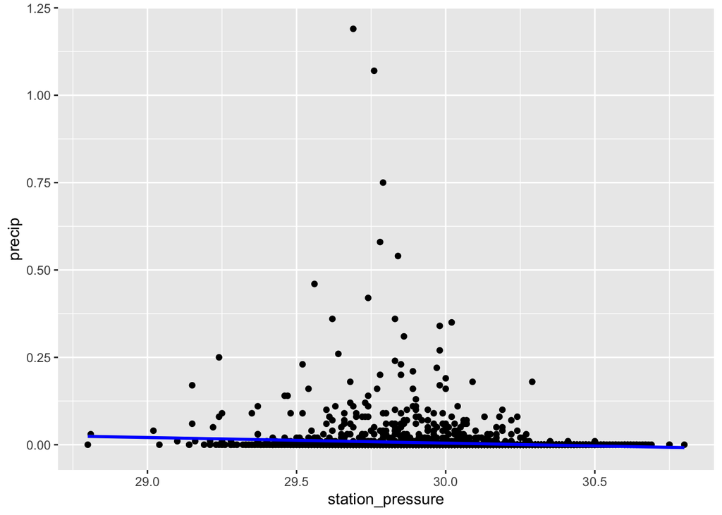

```r
linear_model_stationpressure <- lm(precip ~ station_pressure, data = train_data)
ggplot(train_data, aes(x = station_pressure, y = precip)) +
geom_point() +
stat_smooth(method = "lm", col ="blue")
```

```r
summary(linear_model_humidity)
```

```
##
## Call:
## lm(formula = precip ~ relative_humidity, data = train_data)
##
## Residuals:
##      Min       1Q   Median       3Q      Max
## -0.01395 -0.00866 -0.00392  0.00081  1.17716
##
## Coefficients:
##                     Estimate Std. Error t value Pr(>|t|)
## (Intercept)       -1.390e-02  1.911e-03  -7.274  4.1e-13 ***
## relative_humidity  2.785e-04  2.737e-05  10.177  < 2e-16 ***
## ---
## Signif. codes:  0 '***' 0.001 '**' 0.01 '*' 0.05 '.' 0.1 ' ' 1
##
## Residual standard error: 0.03661 on 4465 degrees of freedom
##   (114 observations deleted due to missingness)
## Multiple R-squared:  0.02267,    Adjusted R-squared:  0.02245
## F-statistic: 103.6 on 1 and 4465 DF,  p-value: < 2.2e-16
```

### Improving the model

After creating a simple linear regression model the next task was to improve the model by adding new features.

Based on the results of the previous models. relative_humidity appeared to have the strongest predictior of precip. However, the results were non-linear and so I created a 10th order polynomial regression model.

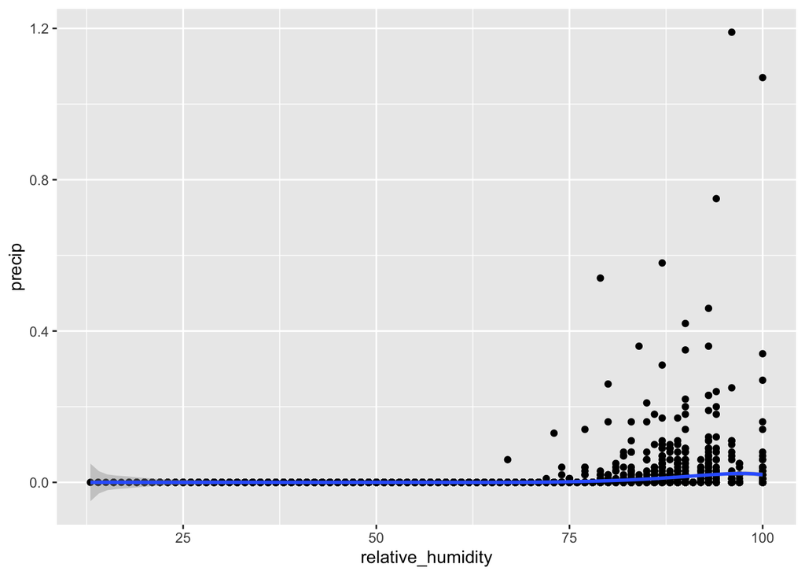

```r
polynomial_relativehumidity <- lm(precip ~ poly(relative_humidity, 10, raw = TRUE), data = train_data)

ggplot(data = train_data, aes(relative_humidity, precip))+
       geom_point() +
       geom_smooth(method = "lm", formula = y ~ poly(x,10))
```

##### Showing a summary of the 10th order polynomial regression model

```r
summary(polynomial_relativehumidity)
```

```
##
## Call:
## lm(formula = precip ~ poly(relative_humidity, 10, raw = TRUE),
##     data = train_data)
##
## Residuals:
##      Min       1Q   Median       3Q      Max
## -0.02341 -0.00497 -0.00006  0.00002  1.16701
##
## Coefficients:
##                                             Estimate Std. Error t value
## (Intercept)                               -1.039e-01  2.327e+00  -0.045
## poly(relative_humidity, 10, raw = TRUE)1   2.843e-02  5.706e-01   0.050
## poly(relative_humidity, 10, raw = TRUE)2  -3.301e-03  5.964e-02  -0.055
## poly(relative_humidity, 10, raw = TRUE)3   2.147e-04  3.513e-03   0.061
## poly(relative_humidity, 10, raw = TRUE)4  -8.697e-06  1.297e-04  -0.067
## poly(relative_humidity, 10, raw = TRUE)5   2.301e-07  3.148e-06   0.073
## poly(relative_humidity, 10, raw = TRUE)6  -4.041e-09  5.106e-08  -0.079
## poly(relative_humidity, 10, raw = TRUE)7   4.675e-11  5.483e-10   0.085
## poly(relative_humidity, 10, raw = TRUE)8  -3.423e-13  3.742e-12  -0.091
## poly(relative_humidity, 10, raw = TRUE)9   1.439e-15  1.469e-14   0.098
## poly(relative_humidity, 10, raw = TRUE)10 -2.650e-18  2.527e-17  -0.105
##                                           Pr(>|t|)
## (Intercept)                                  0.964
## poly(relative_humidity, 10, raw = TRUE)1     0.960
## poly(relative_humidity, 10, raw = TRUE)2     0.956
## poly(relative_humidity, 10, raw = TRUE)3     0.951
## poly(relative_humidity, 10, raw = TRUE)4     0.947
## poly(relative_humidity, 10, raw = TRUE)5     0.942
## poly(relative_humidity, 10, raw = TRUE)6     0.937
## poly(relative_humidity, 10, raw = TRUE)7     0.932
## poly(relative_humidity, 10, raw = TRUE)8     0.927
## poly(relative_humidity, 10, raw = TRUE)9     0.922
## poly(relative_humidity, 10, raw = TRUE)10    0.916
##
## Residual standard error: 0.03639 on 4456 degrees of freedom
##   (114 observations deleted due to missingness)
## Multiple R-squared:  0.03661,    Adjusted R-squared:  0.03445
## F-statistic: 16.93 on 10 and 4456 DF,  p-value: < 2.2e-16
```